# Analysis of Fatal Police Shootings in the United States (2015-2022)

2023-10-05

# Introduction

The dataset *all_police_shootings* used in this analysis is a record of police shootings in the United States from 2015 to 2022 time period. Police shootings are a topic of immense societal concern and have sparked nationwide debates and discussions. Each of these events is a poignant reminder of the intersection of law enforcement, public safety, and individual rights. Such incidents have raised profound questions about the use of force by law enforcement officers, the prevalence of racial disparities, and the broader issues surrounding community safety.  
In this analysis, we are interested in investigating the factors that affect the likelihood of being involved in police shootings.

## Origin of dataset

The dataset (The Washington Post, 2022) used in this analysis, which contains comprehensive information on police-involved killings in the United States, has been meticulously compiled by The Washington Post. Due to the Black Lives Matter protest movement culminated from the 2014 killing of Michael Brown, The Post began to track shootings with circumstances closely paralleling those like the killing of Brown since 2015. The Washington Post documented and tracked details about each police-involved fatality – incidents in which a police officer, in the line of duty, shoots and kills a civilian, through manually culling local news reports, collecting information from law enforcement websites and social media, and monitoring independent databases. This dataset is a valuable resource for understanding and studying incidents of this nature in the United States.

## Motivation

In the past decade, there has been discussions and protests from time to time about racial discrimination, especially when it comes to use of force by authority. This analysis is driven by the imperative to address societal concerns regarding potential racial bias in police shootings in the United States. Amidst nationwide discussions on law enforcement practices, the dataset compiled by The Washington Post serves as a crucial resource to objectively examine and validate claims of disparities. By employing statistical analysis and data visualization, our aim is to contribute evidence-based insights, dispel doubts, and foster informed discussions on this sensitive issue.

# Preliminary work

### Installing .csv file into R

```r
all_police_shootings <- read.csv("data/fatal-police-shootings-data.csv")
```

# Basic Data Analysis

### Summary Statistics

From the first few rows of the dataset, we gain a basic understanding of what information the dataset contains: the name of the person shot, date of incident, manner of death, type of arm equipped, age, gender and race of the person, as well as the geographic information of the incident, represented by city name, state name and longitude and latitude value. The dataset also contains some boolean/binary values that details if the person has signs of mental illness, if the person is fleeing and if the police wears body_camera.  
To begin our analysis, let’s take a look at the first few rows of the dataset. This initial exploration will give us a sense of the data’s structure and the variables it contains.

```r
print(head(all_police_shootings))
```

```
##   id               name     date  manner_of_death      armed age gender race
## 1  3         Tim Elliot 1/2/2015             shot        gun  53      M    A
## 2  4   Lewis Lee Lembke 1/2/2015             shot        gun  47      M    W
## 3  5 John Paul Quintero 1/3/2015 shot and Tasered    unarmed  23      M    H
## 4  8    Matthew Hoffman 1/4/2015             shot toy weapon  32      M    W
## 5  9  Michael Rodriguez 1/4/2015             shot   nail gun  39      M    H
## 6 11  Kenneth Joe Brown 1/4/2015             shot        gun  18      M    W
##            city state signs_of_mental_illness threat_level        flee
## 1       Shelton    WA                    TRUE       attack Not fleeing
## 2         Aloha    OR                   FALSE       attack Not fleeing
## 3       Wichita    KS                   FALSE        other Not fleeing
## 4 San Francisco    CA                    TRUE       attack Not fleeing
## 5         Evans    CO                   FALSE       attack Not fleeing
## 6       Guthrie    OK                   FALSE       attack Not fleeing
##   body_camera longitude latitude is_geocoding_exact
## 1       FALSE  -123.122   47.247               TRUE
## 2       FALSE  -122.892   45.487               TRUE
## 3       FALSE   -97.281   37.695               TRUE
## 4       FALSE  -122.422   37.763               TRUE
## 5       FALSE  -104.692   40.384               TRUE
## 6       FALSE   -97.423   35.877               TRUE
```

Variables:  
*`id`: This variable represents a unique identifier for each incident in the dataset.*  
`name`: The name of the individual involved in the incident, typically the person who was shot by the police.  
*`date`: The date when the incident occurred. It is in the format of mm/dd/yyyy.*  
`manner_of_death`: This variable indicates the manner in which the individual died. It includes values like “shot” or “shot and Tasered”.  
*`armed`: The type of weapon or item that the individual was carrying during the incident, such as “gun,” “unarmed,” or “toy weapon.”*  
`age`: The age of the individual involved in the incident.  
*`gender`: The gender of the individual, recorded as “M” for male or “F” for female.*  
`race`: The race variable categorizes the individual’s racial or ethnic background, recorded as “A” for Asian, “B” for Black, “H” for Hispanic, “N” for Native American, “W” for Whites and “O” for others.  
*`city`: The name of the city where the incident took place.*  
`state`: The name of U.S. state where the incident occurred.  
*`signs_of_mental_illness`: Binary variable (TRUE or FALSE) indicates whether there were signs of mental illness in the individual involved in the incident.*  
`threat_level`: The perceived threat level of the individual during the incident, such as “attack” or “other”.  
*`flee`: The flee variable characterizes the individual’s actions during the incident, including values like “Not fleeing,” “Car,” or “Foot”.* `body_camera`: Binary variable (TRUE or FALSE) specifies whether the police officer involved had a body camera recording during the incident. *`longitude`: The longitude coordinate of the incident location.*  
`latitude`: The latitude coordinate of the incident location.  
*`is_geocoding_exact`: Binary variable (TRUE or FALSE) that indicates if the geocoding of the incident location is considered accurate.

From the summary of data, we gain an overview of the distribution of the variables. We can see the age of the people shot ranges from 2 to 92, averaging to around 37 years old, and in most cases, there is no sign of mental illness with most police not wearing body camera.

```r
summary(all_police_shootings)
```

```
##        id           name               date           manner_of_death
##  Min.   :   3   Length:8002        Length:8002        Length:8002
##  1st Qu.:2240   Class :character   Class :character   Class :character
##  Median :4446   Mode  :character   Mode  :character   Mode  :character
##  Mean   :4415
##  3rd Qu.:6580
##  Max.   :8696
##
##     armed                age           gender              race
##  Length:8002        Min.   : 2.00   Length:8002        Length:8002
##  Class :character   1st Qu.:27.00   Class :character   Class :character
##  Mode  :character   Median :35.00   Mode  :character   Mode  :character
##                     Mean   :37.21
##                     3rd Qu.:45.00
##                     Max.   :92.00
##                     NA's   :503
##      city              state           signs_of_mental_illness
##  Length:8002        Length:8002        Mode :logical
##  Class :character   Class :character   FALSE:6331
##  Mode  :character   Mode  :character   TRUE :1671
##
##
##
##
##  threat_level           flee           body_camera       longitude
##  Length:8002        Length:8002        Mode :logical   Min.   :-160.01
##  Class :character   Class :character   FALSE:6865      1st Qu.:-112.03
##  Mode  :character   Mode  :character   TRUE :1137      Median : -94.31
##                                                        Mean   : -97.04
##                                                        3rd Qu.: -83.15
##                                                        Max.   : -67.87
##                                                        NA's   :840
##     latitude     is_geocoding_exact
##  Min.   :19.50   Mode :logical
##  1st Qu.:33.48   FALSE:18
##  Median :36.10   TRUE :7984
##  Mean   :36.68
##  3rd Qu.:40.03
##  Max.   :71.30
##  NA's   :840
```

# Data Exploration

### Overview

In the dataset, there are a total of 8002 observations and 17 variables.

```r
dim(all_police_shootings)
```

```
## [1] 8002   17
```

### Structure and Missing Data

Gain information about the data type of each variable as well as a preview of some of their possible values.

```r
str(all_police_shootings)
```

```
## 'data.frame':    8002 obs. of  17 variables:
##  $ id                     : int  3 4 5 8 9 11 13 15 16 17 ...
##  $ name                   : chr  "Tim Elliot" "Lewis Lee Lembke" "John Paul Quintero" "Matthew Hoffman" ...
##  $ date                   : chr  "1/2/2015" "1/2/2015" "1/3/2015" "1/4/2015" ...
##  $ manner_of_death        : chr  "shot" "shot" "shot and Tasered" "shot" ...
##  $ armed                  : chr  "gun" "gun" "unarmed" "toy weapon" ...
##  $ age                    : int  53 47 23 32 39 18 22 35 34 47 ...
##  $ gender                 : chr  "M" "M" "M" "M" ...
##  $ race                   : chr  "A" "W" "H" "W" ...
##  $ city                   : chr  "Shelton" "Aloha" "Wichita" "San Francisco" ...
##  $ state                  : chr  "WA" "OR" "KS" "CA" ...
##  $ signs_of_mental_illness: logi  TRUE FALSE FALSE TRUE FALSE FALSE ...
##  $ threat_level           : chr  "attack" "attack" "other" "attack" ...
##  $ flee                   : chr  "Not fleeing" "Not fleeing" "Not fleeing" "Not fleeing" ...
##  $ body_camera            : logi  FALSE FALSE FALSE FALSE FALSE FALSE ...
##  $ longitude              : num  -123.1 -122.9 -97.3 -122.4 -104.7 ...
##  $ latitude               : num  47.2 45.5 37.7 37.8 40.4 ...
##  $ is_geocoding_exact     : logi  TRUE TRUE TRUE TRUE TRUE TRUE ...
```

```r
sapply(all_police_shootings, class)
```

```
##                      id                    name                    date
##               "integer"             "character"             "character"
##         manner_of_death                   armed                     age
##             "character"             "character"               "integer"
##                  gender                    race                    city
##             "character"             "character"             "character"
##                   state signs_of_mental_illness            threat_level
##             "character"               "logical"             "character"
##                    flee             body_camera               longitude
##             "character"               "logical"               "numeric"
##                latitude      is_geocoding_exact
##               "numeric"               "logical"
```

Most variables have no missing values, while there are 840 observations missing longitude and latitude information and 503 entries missing age information. When analysis involve age aspect, observations with missing values will be filtered out for accuracy.

```r
colSums(is.na(all_police_shootings))
```

```
##                      id                    name                    date
##                       0                       0                       0
##         manner_of_death                   armed                     age
##                       0                       0                     503
##                  gender                    race                    city
##                       0                       0                       0
##                   state signs_of_mental_illness            threat_level
##                       0                       0                       0
##                    flee             body_camera               longitude
##                       0                       0                     840
##                latitude      is_geocoding_exact
##                     840                       0
```

## Trends and Patterns

We use frequency tables and visualizations to identify trends and patterns of variables as entry point for closer examination.

### Frequency Tables

From the frequency tables, we can observe that there is a diverse range of weapon types recorded in the dataset. Some observations indicate the presence of a single weapon, while others suggest combinations of multiple weapons used in the incidents.

```r
manner_of_death_freq_table <- table(all_police_shootings$manner_of_death)
armed_freq_table <- table(all_police_shootings$armed)
age_freq_table <- table(all_police_shootings$age)
gender_freq_table <- table(all_police_shootings$gender)
race_freq_table <- table(all_police_shootings$race)
gender_freq_table <- table(all_police_shootings$gender)
state_freq_table <- table(all_police_shootings$state)
mental_illness_freq_table <- table(all_police_shootings$signs_of_mental_illness)
flee_freq_table <- table(all_police_shootings$flee)
body_camera_freq_table <- table(all_police_shootings$body_camera)

print(armed_freq_table)
```

```
##
##                                                   air conditioner
##                              211                                1
##                       air pistol                   Airsoft pistol
##                                2                                6
##                               ax                   ax and machete
##                               30                                1
##                         barstool                     baseball bat
##                                1                               20
##          baseball bat and bottle baseball bat and fireplace poker
##                                1                                1
##           baseball bat and knife                            baton
##                                1                                6
##                           BB gun               BB gun and vehicle
##                               19                                1
##                     bean-bag gun                      beer bottle
##                                1                                3
##                       binoculars                     blunt object
##                                1                                6
##                           bottle                    bow and arrow
##                                3                                2
##                       box cutter                            brick
##                               14                                2
##              car, knife and mace                          carjack
##                                1                                1
##                            chain                        chain saw
##                                3                                2
##                         chainsaw                            chair
##                                1                                4
##              claimed to be armed               contractor's level
##                                1                                1
##                   cordless drill                         crossbow
##                                1                               10
##                          crowbar                        fireworks
##                                5                                1
##                         flagpole                        flare gun
##                                1                                1
##                       flashlight                      garden tool
##                                2                                4
##                      glass shard                              gun
```

[output cut: 54 more lines]

```
##                                1                                5
##                            sword                            Taser
##                               27                               39
##                        tire iron                       toy weapon
##                                6                              248
##                          unarmed                     undetermined
##                              460                              338
##                   unknown weapon                          vehicle
##                              121                              284
##                  vehicle and gun              vehicle and machete
##                               10                                1
##                    walking stick                       wasp spray
##                                1                                1
##                           wrench
##                                1
```

```r
all_police_shootings$multiple_weapon <- grepl("and", all_police_shootings$armed)
all_police_shootings$flee_TF <- grepl("Not fleeing", all_police_shootings$flee)
```

From the frequency table of weapon categories, we can see varieties of weapons being recorded. To better analyze the impact of weapon type, we need to classify them into categories.

```r
# data cleaning and manipulation
weapon_categories <- c(
  "Air Weapons",
  "Blunt Objects",
  "Edged Weapons",
  "Explosives",
  "Firearms",
  "Hand Tools",
  "Melee Weapons",
  "Metal Objects",
  "Piercing Weapons",
  "Projectiles",
  "Sharp Objects",
  "Sticks/Poles",
  "Unarmed",
  "Undetermined",
  "Vehicles"
)

# Create subcategories for each variable
air_weapons <- c("air conditioner", "air pistol", "Airsoft pistol")
blunt_objects <- c("barstool", "baseball bat", "baseball bat and bottle", "baseball bat and fireplace poker", "baseball bat and knife", "baton")
edged_weapons <- c("ax", "ax and machete", "bow and arrow", "box cutter", "car, knife and mace", "carjack", "chain", "chain saw", "chainsaw", "contractor's level", "crowbar", "machete", "machete and hammer", "meat cleaver", "pick-axe", "railroad spikes", "samurai sword")
explosives <- c("fireworks", "incendiary device", "incendiary weapon")
firearms <- c("BB gun", "BB gun and vehicle", "gun", "Gun", "gun and car", "gun and knife", "gun and machete", "gun and sword", "gun and vehicle", "guns and explosives")
hand_tools <- c("cordless drill", "flashlight", "garden tool", "hand torch", "metal hand tool", "metal object", "metal pipe", "metal pole", "metal rake", "metal stick", "microphone", "nail gun", "pipe", "screwdriver", "wrench")
melee_weapons <- c("beer bottle", "bottle", "chair", "gun", "incendiary weapon", "knife", "knife and vehicle", "knife, hammer and gasoline can", "lawn mower blade", "machete and gun", "spear", "straight edge razor", "sword", "Taser")
metal_objects <- c("chain", "hammer", "metal hand tool", "metal object", "metal pipe", "metal pole", "metal rake", "metal stick", "nail gun", "pipe", "screwdriver", "wrench")
piercing_weapons <- c("ax", "ax and machete", "bow and arrow", "box cutter", "car, knife and mace", "carjack", "crowbar", "machete", "machete and hammer", "meat cleaver", "pick-axe", "railroad spikes", "samurai sword", "screwdriver")
projectiles <- c("crossbow", "flare gun")
sharp_objects <- c("glass shard", "knife", "knife and vehicle", "pair of scissors")
sticks_poles <- c("flagpole", "pole", "pole and knife", "stapler")
unarmed <- c("unarmed", "undetermined", "unknown weapon")
vehicles <- c("vehicle", "vehicle and gun", "vehicle and machete", "walking stick")

# Create a list of these subcategories
weapon_list <- list(air_weapons, blunt_objects, edged_weapons, explosives, firearms, hand_tools, melee_weapons, metal_objects, piercing_weapons, projectiles, sharp_objects, sticks_poles, unarmed, vehicles)

# Create variables
for (i in 1:14) {
  assign(weapon_categories[i], weapon_list[[i]])
}

all_police_shootings <- all_police_shootings %>%
  mutate(weapon_categories = case_when(
    armed %in% air_weapons ~ "Air Weapons",
    armed %in% blunt_objects ~ "Blunt Objects",
    armed %in% edged_weapons ~ "Edged Weapons",
    armed %in% explosives ~ "Explosives",
    armed %in% firearms ~ "Firearms",
    armed %in% hand_tools ~ "Hand Tools",
    armed %in% melee_weapons ~ "Melee Weapons",
    armed %in% metal_objects ~ "Metal Objects",
    armed %in% piercing_weapons ~ "Piercing Weapons",
    armed %in% projectiles ~ "Projectiles",
    armed %in% sharp_objects ~ "Sharp Objects",
    armed %in% sticks_poles ~ "Sticks/Poles",
    armed %in% unarmed ~ "Unarmed",
    armed %in% vehicles ~ "Vehicles",
    TRUE ~ "Other"
  ))

# change names for people to better understand
all_police_shootings$race <- factor(all_police_shootings$race, levels = c("A", "B", "H", "N","O", "W"), labels = c("Asian", "Black","Hispanic","Native American", "Others", "White"))
```

This gender distribution highlights a significant disparity, with a substantially higher number of male individuals involved in the recorded incidents compared to their female counterparts.

```r
print(gender_freq_table)
```

```
##
##         F    M
##   31  358 7613
```

The gender distribution reveals a substantial imbalance, with a significantly larger number of male individuals involved in the documented incidents when compared to their female counterparts. It’s essential to point out that while our initial check using the `is.na()` function showed no missing values in the “gender” variable, it’s worth noting that the dataset contains a few empty string values that are not coded as NULL. These empty string values will be addressed during future data preprocessing for a more comprehensive analysis.

Let’s examine the frequency of racial backgrounds in the dataset using a race frequency table. The largest group within the dataset is comprised of White individuals, followed by Black and Hispanic individuals. In contrast, the dataset includes a smaller proportion of Asian individuals.

```r
print(race_freq_table)
```

```
##
##         A    B    H    N    O    W
## 1517  129 1766 1166  105   19 3300
```

The proportion of people reported to have mental illness are higher than average proportion in real life, which makes it one of the possible factors that affect the likelihood of being involved in police shootings incidents.

```r
print(mental_illness_freq_table)
```

```
##
## FALSE  TRUE
##  6331  1671
```

This frequency table that shows the distribution of different categories related to how individuals involved in recorded police shooting incidents attempted to flee the scene. Here we note that that dataset contains some empty string values that needs to be addressed before analyzed.

```r
print(flee_freq_table)
```

```
##
##                     Car        Foot Not fleeing       Other
##         966        1289        1022        4430         295
```

```r
print(body_camera_freq_table)
```

```
##
## FALSE  TRUE
##  6865  1137
```

```r
# extract date and cast to type Date
all_police_shootings$date <- all_police_shootings$date %>% as.Date(format = "%m/%d/%Y")
# extract day and store in day variable
all_police_shootings$day <- all_police_shootings$date %>% as.Date(format = "%m/%d/%Y") %>% format(format = "%d")
# extract month and store in month variable
all_police_shootings$month <- all_police_shootings$date %>% as.Date(format = "%m/%d/%Y") %>% format(format = "%m")
# extract year and store in year variable
all_police_shootings$year <- all_police_shootings$date %>% as.Date(format = "%m/%d/%Y") %>% format(format = "%Y")
```

# Visualizations

The line plot provides an overview of the trend in the population involved in police shootings spanning from 2015 to 2022. There is a dip in the year 2016 and 2022; however, the overall trend reveals a steady increase in incidents over this period, indicating a rising occurrence of such events.

The data unveils a compelling trend in the realm of police shootings over the past few years, shedding light on noteworthy shifts in the frequency of these incidents. Since 2018, there has been a discernible and steady increase in the number of police shootings. This escalation could be attributed to various factors, including changes in law enforcement practices, community dynamics, and social unrest. It underscores the urgent need for proactive measures to address and mitigate the occurrence of such incidents.

However, 2022 stands out as an exception to this upward trajectory. Notably, the data reveals a decline in the number of police shootings during this year compared to the preceding year, 2021. This drop marks a significant departure from the previously observed trend, suggesting a potential positive development in the realm of law enforcement and community interactions. It indicates that efforts and reforms aimed at reducing the frequency of police shootings may be taking effect.

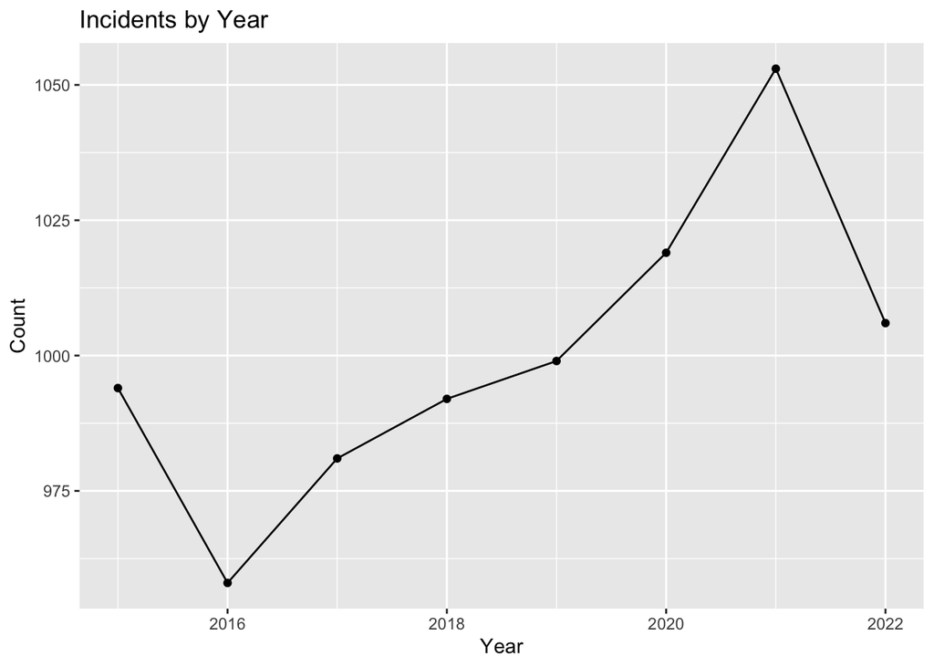

```r
# how the number of incidents per year changes
counts_by_year <- table(all_police_shootings$year)
counts_by_year_df <- data.frame(Year = as.integer(names(counts_by_year)), Incidents = counts_by_year)

counts_by_year_df %>% ggplot(aes(x = Year, y = Incidents.Freq)) + geom_line() + geom_point() +
  labs(title = "Incidents by Year", x = "Year", y = "Count")
```

From the line chart congregating the incidents by months, there is a decreasing trend toward the end of the year. However, overall we don’t see compelling evidence for seasonality.

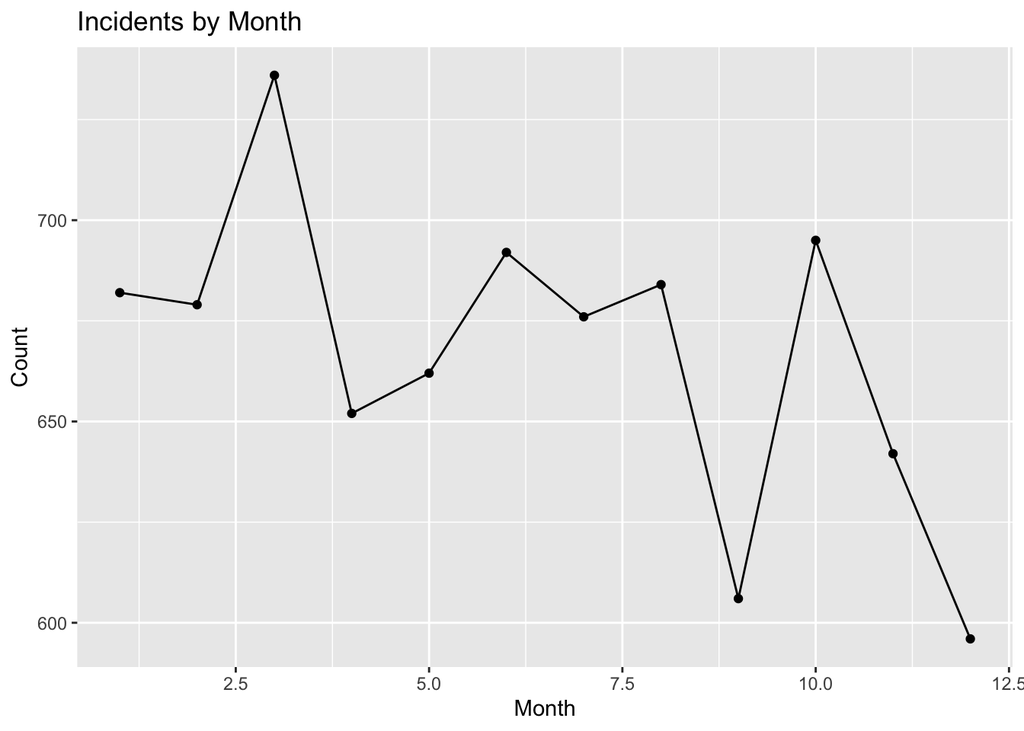

```r
# how the number of incidents by month changes
counts_by_month <- table(all_police_shootings$month)
counts_by_month_df <- data.frame(Month = as.integer(names(counts_by_month)), Incidents = counts_by_month)

counts_by_month_df %>% ggplot(aes(x = Month, y = Incidents.Freq)) + geom_line() + geom_point() +
  labs(title = "Incidents by Month", x = "Month", y = "Count")
```

The age distribution of individuals involved in these incidents, as revealed by the data, exhibits a noteworthy pattern characterized by a bell-shaped curve. This distribution indicates a concentration of individuals primarily within the age range of 20 to 40 years old. The prevalence of individuals falling within this age bracket raises several intriguing points that invite further examination and analysis.

One possible explanation for this concentration of age groups in police shooting incidents during this specific phase of life relates to the intersection of various factors. At this age, individuals often experience a confluence of heightened physical capabilities, increased social interactions, and, sometimes, a greater propensity for challenging or high-risk situations. The period between the ages of 20 and 40 typically corresponds with the prime of one’s physical abilities, marked by strength and agility. This factor might influence the nature of interactions with law enforcement during encounters, potentially leading to a higher likelihood of confrontational or physically challenging scenarios.

Moreover, this phase of life frequently involves significant social interactions, including employment, relationships, and community engagement. These interactions, while often positive, can also introduce individuals to various situations that may escalate into confrontations with law enforcement.

To better understand the reasons behind this age distribution, future research could delve deeper into the specific contexts and circumstances surrounding these encounters. It’s essential to consider factors such as socio-economic conditions, mental health, and the role of law enforcement practices to comprehensively evaluate this phenomenon. By doing so, we can develop a more nuanced understanding of the dynamics at play during police encounters within this age group and work towards crafting more effective strategies for de-escalation and conflict resolution.

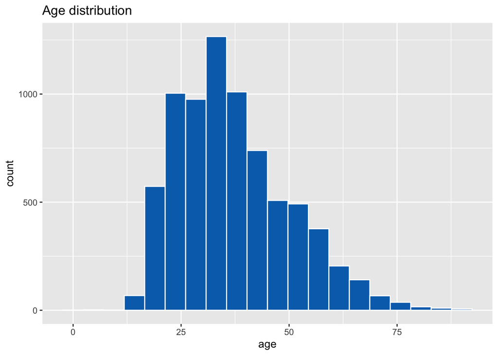

```r
all_police_shootings %>% filter(!is.na(age)) %>%
  ggplot(aes(x = age)) + geom_histogram(bins = 20, fill = '#006FB9', color = 'white') +
  ggtitle ("Age distribution")
```

The bar plot depicting the gender distribution within the dataset offers a stark and easily interpretable visual representation of the significant gender disparity in police shootings. This gender imbalance, with a considerably higher number of males involved in these incidents compared to females, is a salient observation that raises critical questions regarding the factors contributing to this disproportion.

One potential explanation for this gender disparity is rooted in social and behavioral dynamics. It is well-established that societal norms and expectations often shape gender-specific behavior, and these norms can influence interactions with law enforcement. For example, males may, on average, exhibit a higher propensity for aggressive or confrontational behavior during encounters with the police. While it is essential to avoid broad generalizations, this gender-based variation in behavior patterns may contribute to the higher representation of males in police shootings.

This data prompts further investigation into the nuances of these encounters and the role that gender dynamics play. Analyzing the nature of these interactions and the motivations behind individuals’ behavior during police encounters can shed light on the underlying causes of the gender disparity in police shootings.

Moreover, this observation underscores the importance of training and equipping law enforcement agencies to handle encounters with individuals of all genders effectively. It emphasizes the need for gender-sensitive policing strategies that prioritize de-escalation and conflict resolution techniques. Addressing this issue requires a multifaceted approach that considers not only gender dynamics but also the broader context of policing and law enforcement practices.

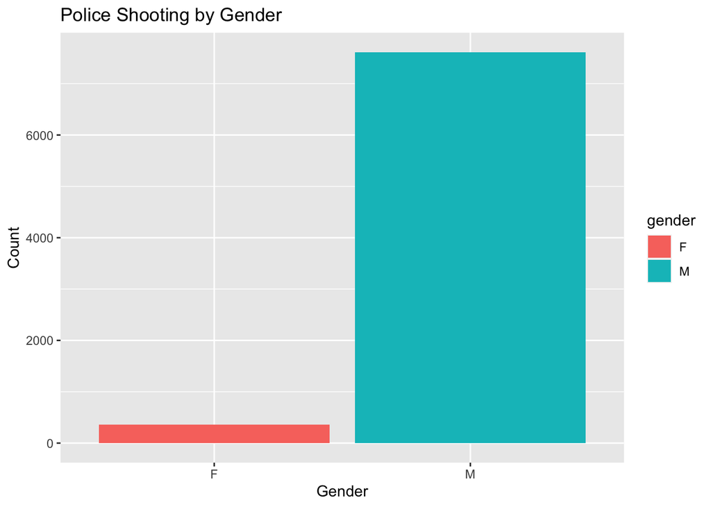

```r
all_police_shootings %>% filter(gender != "") %>% ggplot(aes(x = gender, fill = gender)) + geom_bar() +
  xlab("Gender") + ylab("Count") + ggtitle("Police Shooting by Gender")
```

It is noteworthy that the data reveals a marked disparity in the number of males involved in police shootings compared to females, with a significant preponderance of male individuals within these incidents. This gender imbalance points to the need for a closer examination of the underlying factors that might contribute to this discrepancy, such as societal roles, behavioral patterns, or law enforcement interactions. Such an investigation can offer valuable insights into the dynamics of these incidents.

Interestingly, within each of the gender groups, the age distribution follows a comparable pattern. This finding implies that, despite the pronounced difference in gender representation, individuals of all ages, both male and female, are affected by police shootings in a manner that demonstrates some degree of similarity. This pattern suggests that age, to some extent, is not a defining factor in differentiating the likelihood of individuals becoming embroiled in these incidents within the same gender categories.

Understanding the uniformity in age distribution within gender groups can prompt a more nuanced analysis of the factors influencing police shootings. It is crucial to explore how variables such as race, socio-economic status, mental health, and law enforcement practices might intersect with gender to contribute to the disparities observed. This knowledge can inform more targeted interventions and policies, enabling a comprehensive approach to addressing and mitigating the incidence of police-involved shootings, considering both gender-specific and broader factors.

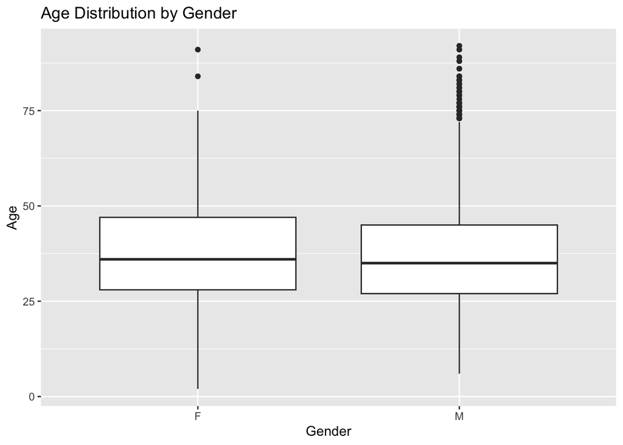

```r
all_police_shootings %>% filter(gender != "") %>% ggplot(aes(x = gender, y = age)) + geom_boxplot() +
  xlab("Gender") + ylab("Age") + ggtitle("Age Distribution by Gender")
```

A crucial aspect of the dataset that demands our attention is the significant discrepancy in the number of individuals involved in police shootings among different racial groups. As observed, there are notably more White individuals involved in these incidents compared to the smaller numbers of individuals of Asian and Native American descent. This discrepancy can partially be attributed to the demographics of the United States, where White Americans constitute a substantial majority, making up approximately 75% of the population. The higher representation of White individuals in police shooting incidents could be, in part, a reflection of their larger demographic presence.

However, a striking contrast emerges when we consider the involvement of Black individuals in police shootings. While Black Americans make up approximately 15% of the U.S. population, their representation in police shootings is disproportionately high, nearly half that of White individuals. This observation raises pertinent questions about the underlying factors contributing to this disparity.

To understand the reasons behind this disproportion, further investigation is warranted. Numerous factors may contribute to this concerning trend, including systemic bias, socioeconomic disparities, and disparities in law enforcement practices. It is imperative to delve deeper into the data to ascertain whether racial bias, stereotyping, or other elements play a role in the higher involvement of Black individuals in police shooting incidents.

In addressing this issue, research should focus on uncovering the root causes and examining potential areas for reform within the criminal justice system, policing practices, and broader societal structures. Policymakers and law enforcement agencies need to consider these disparities seriously and implement measures that ensure equitable and fair treatment for all citizens, regardless of their racial or ethnic background. By doing so, we can aim to rectify the imbalances revealed by the data and work towards a more just and inclusive society where incidents of police shootings are more evenly distributed among all racial groups.

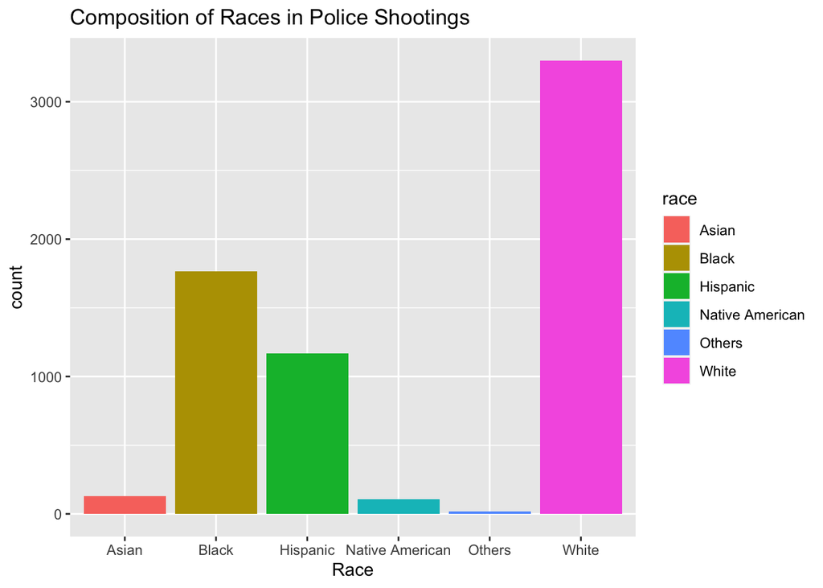

```r
all_police_shootings %>% filter(race != "") %>% ggplot(aes(x = race, fill = race)) + geom_bar() +
    labs(title = "Composition of Races in Police Shootings") +
    xlab("Race")
```

Upon closer examination of the dataset, it becomes evident that the age distribution within each racial group showcases some commonalities with only marginal disparities. This observation implies that, across various racial categories, the occurrences of individuals involved in police shootings tend to span a relatively similar range of ages. This might suggest that age, to some extent, does not significantly differentiate the likelihood of becoming embroiled in these incidents within the racial categories.

However, a noteworthy exception to this trend can be found within the White racial group. Here, the age distribution displays a notably broader span of age groups compared to other racial groups. This peculiarity implies that police-involved shootings involving individuals of White ethnicity encompass a more extensive age range, potentially indicating a higher degree of variability in terms of the age of individuals affected.

The reasons underlying this age distribution disparity within the White racial group are multifaceted and warrant further investigation. It may be influenced by various factors, including demographic composition, regional differences, or socio-economic conditions. Understanding this age-related variation can be pivotal in crafting targeted interventions and policies aimed at reducing police shootings and enhancing safety within communities, with a specific focus on the White racial group to address their unique characteristics and needs.

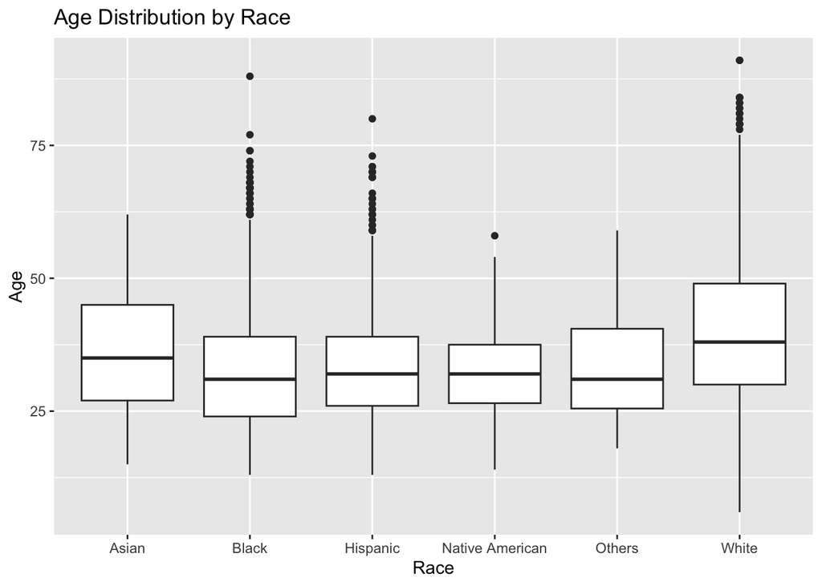

```r
all_police_shootings %>% filter(race != "") %>% ggplot(aes(x = race, y = age)) + geom_boxplot() +
  xlab("Race") + ylab("Age") + ggtitle("Age Distribution by Race")
```

The histogram provides a visual representation of the distribution of police shootings across various weapon categories. Notably, a significant proportion of individuals involved in these incidents were armed with firearms. Following behind are incidents involving melee weapons and unarmed individuals.

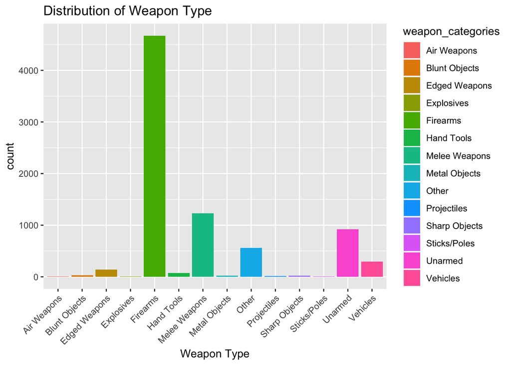

```r
all_police_shootings %>% ggplot(aes(x = weapon_categories, fill = weapon_categories)) + geom_bar() +
  xlab("Weapon Type") + ggtitle("Distribution of Weapon Type") + theme(axis.text.x = element_text(angle = 45, hjust = 1))
```

The following plot offers a detailed breakdown of the racial distribution within each weapon category. It reveals that, across all category types, the distribution of races follows a consistent pattern, mirroring the overall racial composition of the dataset. This observation suggests that the distribution of races within weapon categories aligns with the broader demographic representation in the dataset.

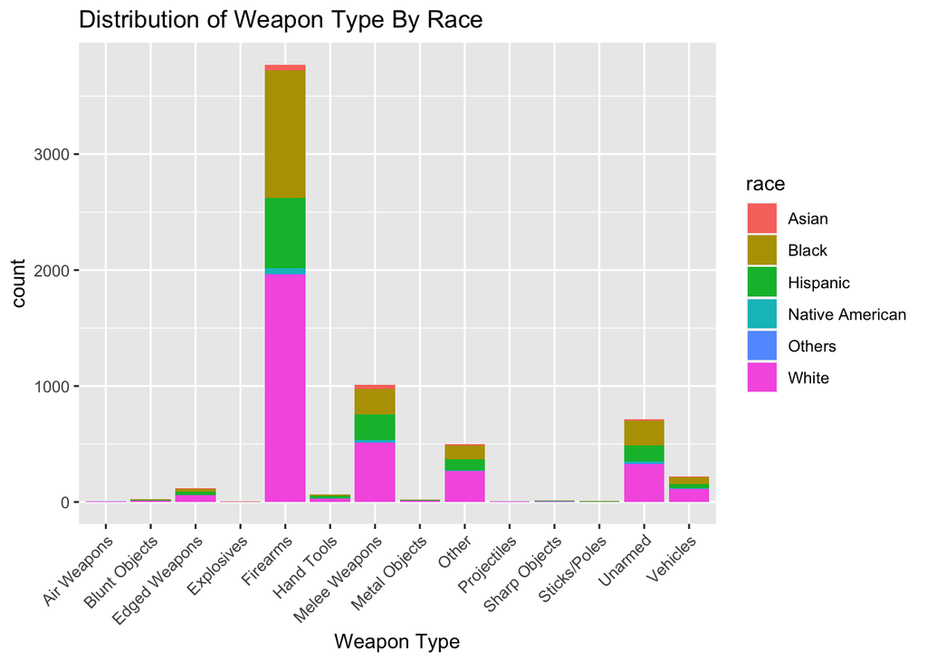

```r
all_police_shootings %>% filter(race != "") %>% ggplot(aes(x = weapon_categories, fill = race)) + geom_bar() +
  xlab("Weapon Type") + ggtitle("Distribution of Weapon Type By Race") + theme(axis.text.x = element_text(angle = 45, hjust = 1))
```

An intriguing aspect of the data that deserves closer scrutiny is the behavior of individuals involved in police shooting incidents within each racial group. In the majority of cases across all racial categories, it is evident that not fleeing occurred more frequently than fleeing. This statistic underscores a noteworthy pattern: most police shooting cases involve individuals who did not attempt to run away or evade law enforcement in any way. This finding raises pertinent questions about the circumstances leading up to these incidents, as well as the interactions between individuals and the police.

This behavioral analysis raises several critical points. The prevalence of subjects choosing to flee in a vehicle may reflect the ease of access and immediate mobility provided by cars in comparison to on-foot escapes. It is essential to further investigate the dynamics surrounding these escape decisions to develop a nuanced understanding of the motivations behind such choices. This knowledge can contribute to the development of policies and training programs for law enforcement to effectively manage situations where fleeing occurs, ensuring the safety of both individuals and officers. Additionally, examining these patterns in the context of racial groups can provide insights into potential disparities and bias within policing practices that warrant careful examination and reform.

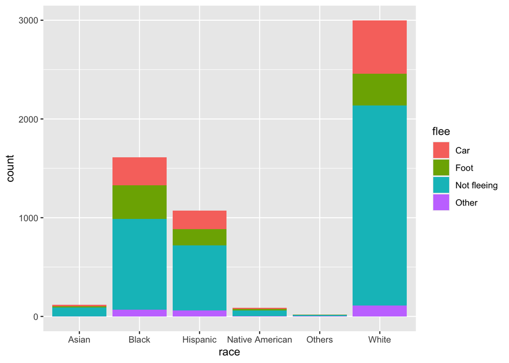

```r
all_police_shootings %>% filter(flee != "" & race != "") %>%
  ggplot(aes(x = race, fill = flee)) + geom_bar()
```

In the scatter plot visualizing the geographical distribution of people involved in these incidents by gender, some intriguing patterns emerge. Notably, the data reveals that the majority of incidents are concentrated in two specific regions: the eastern region and the border/coastal region. This concentration might suggest that these areas experience a higher frequency of police-involved shootings, possibly due to various socio-economic, demographic, or law enforcement factors.

Interestingly, when examining gender disparities, the data illustrates that the geographical distribution is not equal. More specifically, the eastern region seems to witness a higher involvement of females compared to the western region. This gender-related variation could be influenced by a multitude of factors such as population demographics, social dynamics, and law enforcement practices that differ between regions.

This insight into the geographical distribution of police shootings by gender offers a valuable perspective for further research and policy considerations. It underscores the need to investigate why certain areas experience a higher prevalence of such incidents and why there is a gender imbalance in these occurrences. Such knowledge is essential for developing targeted strategies and interventions to mitigate the factors contributing to these unfortunate incidents and to promote a safer and more equitable society.

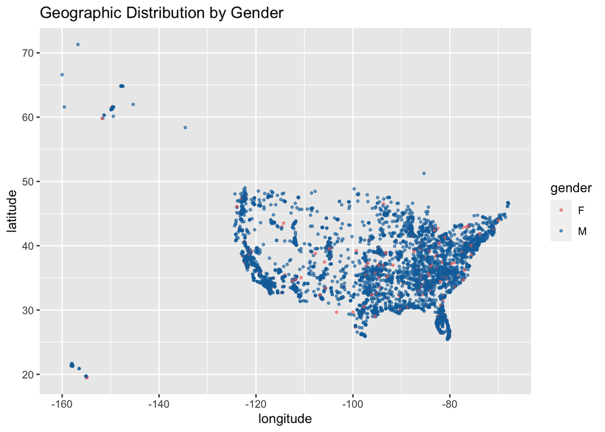

```r
all_police_shootings %>% filter(!is.na(longitude) & !is.na(latitude) & gender != "") %>%
  ggplot(aes(x = longitude, y = latitude, color = gender)) + geom_point(alpha=0.6, size = 0.7) +
  scale_color_manual(values = c("#EF6F6A", "#1170AA")) + ggtitle("Geographic Distribution by Gender")
```

Given the global impact of Covid-19 in 2020, there is a natural curiosity about how this unprecedented event might have influenced various aspects of our lives. In this context, we explore the distribution of police shootings by gender in 2019, a year before the pandemic emerged.

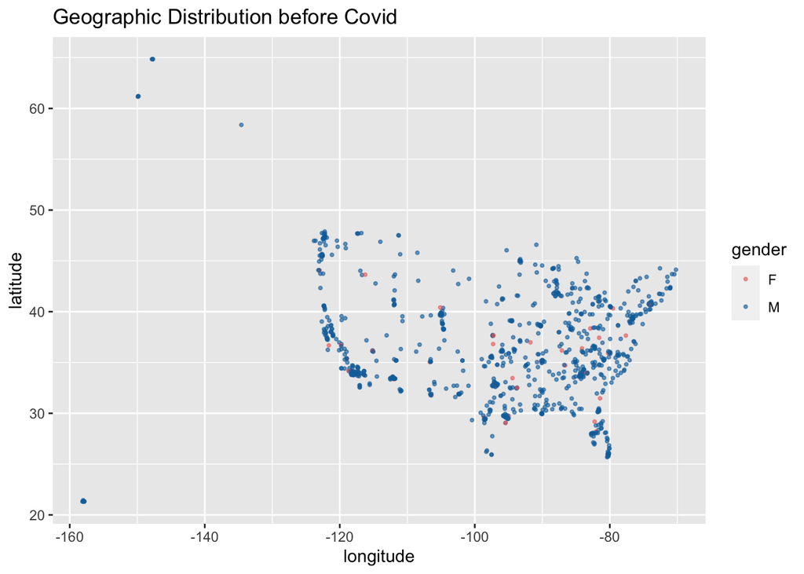

```r
all_police_shootings %>% filter(!is.na(longitude) & !is.na(latitude) & gender != "" & year == 2019) %>%
  ggplot(aes(x = longitude, y = latitude, color = gender)) + geom_point(alpha=0.6, size = 0.7) +
  scale_color_manual(values = c("#EF6F6A", "#1170AA")) + ggtitle("Geographic Distribution before Covid")
```

To provide a point of comparison, the following plot presents the distribution of police shootings after the onset of Covid-19 in 2020. Surprisingly, both distributions exhibit similar patterns, indicating a level of consistency with the broader trends observed over the years. This suggests that the Covid pandemic does not impact the trend of the geographic distribution of police shootings incidents.

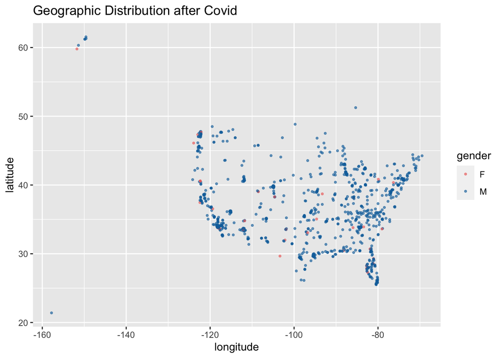

```r
all_police_shootings %>% filter(!is.na(longitude) & !is.na(latitude) & gender != "" & year == 2020) %>%
  ggplot(aes(x = longitude, y = latitude, color = gender)) + geom_point(alpha=0.6, size = 0.7) +
  scale_color_manual(values = c("#EF6F6A", "#1170AA")) + ggtitle("Geographic Distribution after Covid")
```

# Research Questions

The dataset at hand offers a wealth of research opportunities, encompassing various dimensions of police-involved shootings. A particularly promising avenue for exploration revolves around the potential associations between demographic factors and the likelihood of individuals becoming involved in such incidents. By scrutinizing these variables, researchers can better comprehend whether age, race, or gender play a role in the likelihood of being subjected to police shootings. This analysis could illuminate disparities and potentially identify groups that are disproportionately affected, providing vital information for policy-makers and law enforcement agencies seeking to address these disparities.

We have seen trends and patterns displayed by different variables, Thinking over the variables, we realized that rather than police having bias towards one specific group of individuals, it might actually be the related to level that the police find themselves being threatened, which leads to our research question that “How does the perceived level of threat impact hte occurrence of police shootings throughout the United States”.

## Modeling and testing

From the following Chi-Squared models, we can see highly significant relationships between gender and weapon categories as well as between race and weapon categories.

```r
# further processing for modeling
# please delete this comment Sahil if you ever check out this file...
all_police_shootings <- all_police_shootings %>%
  mutate(armed_bool = armed == "unarmed")
all_police_shootings <- all_police_shootings %>%
  mutate(is_firearm = weapon_categories == "Firearms")

# Chi-Squared model (gender ~ weapon categories)
result <- chisq.test(table(all_police_shootings$gender, all_police_shootings$weapon_categories))
print(result)
```

```
##
##  Pearson's Chi-squared test
##
## data:  table(all_police_shootings$gender, all_police_shootings$weapon_categories)
## X-squared = 107.9, df = 26, p-value = 6.03e-12
```

```r
# Chi-Squared model (race ~ weapon categories)
result <- chisq.test(table(all_police_shootings$race, all_police_shootings$weapon_categories))
print(result)
```

```
##
##  Pearson's Chi-squared test
##
## data:  table(all_police_shootings$race, all_police_shootings$weapon_categories)
## X-squared = 194.94, df = 65, p-value = 6.598e-15
```

There is only evidence for relationship between the Whites (p=0.00231) and wearing body cameras. Therefore, there is no evidence for officers posing discrimination towards raical minorities.

```r
# effect of body camera
logistic_model <- glm(body_camera ~ race, data = all_police_shootings, family = "binomial")
summary(logistic_model)
```

```
##
## Call:
## glm(formula = body_camera ~ race, family = "binomial", data = all_police_shootings)
##
## Deviance Residuals:
##     Min       1Q   Median       3Q      Max
## -0.6709  -0.5685  -0.4884  -0.4884   2.1219
##
## Coefficients:
##                     Estimate Std. Error z value Pr(>|z|)
## (Intercept)         -1.37663    0.21948  -6.272 3.56e-10 ***
## raceBlack           -0.02103    0.22745  -0.092  0.92635
## raceHispanic        -0.36404    0.23436  -1.553  0.12035
## raceNative American -0.26749    0.34403  -0.778  0.43685
## raceOthers          -0.76343    0.77906  -0.980  0.32712
## raceWhite           -0.68958    0.22629  -3.047  0.00231 **
## ---
## Signif. codes:  0 '***' 0.001 '**' 0.01 '*' 0.05 '.' 0.1 ' ' 1
##
## (Dispersion parameter for binomial family taken to be 1)
##
##     Null deviance: 5367.6  on 6484  degrees of freedom
## Residual deviance: 5296.8  on 6479  degrees of freedom
##   (1517 observations deleted due to missingness)
## AIC: 5308.8
##
## Number of Fisher Scoring iterations: 4
```

Exploring the relationships between race and having firearm, we found highly significant relationships for race Black (p=4.07e-06) and race Whites (p=4.76e-05), which are the two races that have makes up the highest numbers of population in the dataset.

```r
logistic_model <- glm(is_firearm ~ race, data = all_police_shootings, family = "binomial")
summary(logistic_model)
```

```
##
## Call:
## glm(formula = is_firearm ~ race, family = "binomial", data = all_police_shootings)
##
## Deviance Residuals:
##     Min       1Q   Median       3Q      Max
## -1.3933  -1.3431   0.9758   1.0203   1.3338
##
## Coefficients:
##                     Estimate Std. Error z value Pr(>|z|)
## (Intercept)          -0.3604     0.1790  -2.014   0.0440 *
## raceBlack             0.8550     0.1856   4.608 4.07e-06 ***
## raceHispanic          0.4359     0.1883   2.315   0.0206 *
## raceNative American   0.1886     0.2653   0.711   0.4772
## raceOthers            0.2551     0.4931   0.517   0.6049
## raceWhite             0.7420     0.1824   4.067 4.76e-05 ***
## ---
## Signif. codes:  0 '***' 0.001 '**' 0.01 '*' 0.05 '.' 0.1 ' ' 1
##
## (Dispersion parameter for binomial family taken to be 1)
##
##     Null deviance: 8815.7  on 6484  degrees of freedom
## Residual deviance: 8760.8  on 6479  degrees of freedom
##   (1517 observations deleted due to missingness)
## AIC: 8772.8
##
## Number of Fisher Scoring iterations: 4
```

## Citation

The Washington Post. (2022). Fatal Force Database. https://github.com/washingtonpost/data-police-shootings/blob/master/v1/fatal-police-shootings-data.csv